# Risk Factor Analysis

## Outcome Variable

**Outcome Variable:** stunted

## Predictor Variables

**Intervention Variable:** tr

**Adjustment Set:**

unadjusted

## Stratifying Variables

The analysis was stratified on these variable(s):

- mbmi
- agecat
- studyid
- country

## Data Summary

| mbmi | agecat | studyid | country | tr | stunted | n_cell | n |
| --- | --- | --- | --- | --- | --- | --- | --- |
| [25-30) | 24 months | ki1000110-WASH-Bangladesh | BANGLADESH | Control | 0 | 18 | 95 |
| [25-30) | 24 months | ki1000110-WASH-Bangladesh | BANGLADESH | Control | 1 | 5 | 95 |
| [25-30) | 24 months | ki1000110-WASH-Bangladesh | BANGLADESH | LNS | 0 | 22 | 95 |
| [25-30) | 24 months | ki1000110-WASH-Bangladesh | BANGLADESH | LNS | 1 | 6 | 95 |
| [25-30) | 24 months | ki1000110-WASH-Bangladesh | BANGLADESH | Other | 0 | 31 | 95 |
| [25-30) | 24 months | ki1000110-WASH-Bangladesh | BANGLADESH | Other | 1 | 13 | 95 |
| [18.5-25) | 24 months | ki1000110-WASH-Bangladesh | BANGLADESH | Control | 0 | 101 | 699 |
| [18.5-25) | 24 months | ki1000110-WASH-Bangladesh | BANGLADESH | Control | 1 | 64 | 699 |
| [18.5-25) | 24 months | ki1000110-WASH-Bangladesh | BANGLADESH | LNS | 0 | 110 | 699 |
| [18.5-25) | 24 months | ki1000110-WASH-Bangladesh | BANGLADESH | LNS | 1 | 67 | 699 |
| [18.5-25) | 24 months | ki1000110-WASH-Bangladesh | BANGLADESH | Other | 0 | 209 | 699 |
| [18.5-25) | 24 months | ki1000110-WASH-Bangladesh | BANGLADESH | Other | 1 | 148 | 699 |
| <18.5 | 24 months | ki1000110-WASH-Bangladesh | BANGLADESH | Control | 0 | 36 | 384 |
| <18.5 | 24 months | ki1000110-WASH-Bangladesh | BANGLADESH | Control | 1 | 46 | 384 |
| <18.5 | 24 months | ki1000110-WASH-Bangladesh | BANGLADESH | LNS | 0 | 57 | 384 |
| <18.5 | 24 months | ki1000110-WASH-Bangladesh | BANGLADESH | LNS | 1 | 43 | 384 |
| <18.5 | 24 months | ki1000110-WASH-Bangladesh | BANGLADESH | Other | 0 | 111 | 384 |
| <18.5 | 24 months | ki1000110-WASH-Bangladesh | BANGLADESH | Other | 1 | 91 | 384 |
| [18.5-25) | 6 months | ki1000110-WASH-Bangladesh | BANGLADESH | Control | 0 | 83 | 432 |
| [18.5-25) | 6 months | ki1000110-WASH-Bangladesh | BANGLADESH | Control | 1 | 17 | 432 |
| [18.5-25) | 6 months | ki1000110-WASH-Bangladesh | BANGLADESH | LNS | 0 | 104 | 432 |
| [18.5-25) | 6 months | ki1000110-WASH-Bangladesh | BANGLADESH | LNS | 1 | 16 | 432 |
| [18.5-25) | 6 months | ki1000110-WASH-Bangladesh | BANGLADESH | Other | 0 | 191 | 432 |
| [18.5-25) | 6 months | ki1000110-WASH-Bangladesh | BANGLADESH | Other | 1 | 21 | 432 |
| >=30 | 6 months | ki1000110-WASH-Bangladesh | BANGLADESH | LNS | 0 | 1 | 7 |
| >=30 | 6 months | ki1000110-WASH-Bangladesh | BANGLADESH | Other | 0 | 6 | 7 |
| [25-30) | 6 months | ki1000110-WASH-Bangladesh | BANGLADESH | Control | 0 | 5 | 34 |
| [25-30) | 6 months | ki1000110-WASH-Bangladesh | BANGLADESH | Control | 1 | 0 | 34 |
| [25-30) | 6 months | ki1000110-WASH-Bangladesh | BANGLADESH | LNS | 0 | 7 | 34 |
| [25-30) | 6 months | ki1000110-WASH-Bangladesh | BANGLADESH | LNS | 1 | 0 | 34 |

[output cut: 269 more lines]

The following strata were considered:

- mbmi: [18.5-25), agecat: 24 months, studyid: ki1000110-WASH-Bangladesh, country: BANGLADESH
- mbmi: [18.5-25), agecat: 24 months, studyid: ki1017093b-PROVIDE, country: BANGLADESH
- mbmi: [18.5-25), agecat: 24 months, studyid: ki1066203-TanzaniaChild2, country: TANZANIA, UNITED REPUBLIC OF
- mbmi: [18.5-25), agecat: 24 months, studyid: ki1112895-Burkina Faso Zn, country: BURKINA FASO
- mbmi: [18.5-25), agecat: 24 months, studyid: ki1119695-PROBIT, country: BELARUS
- mbmi: [18.5-25), agecat: 24 months, studyid: ki1126311-ZVITAMBO, country: ZIMBABWE
- mbmi: [18.5-25), agecat: 24 months, studyid: ki1148112-iLiNS-DOSE, country: MALAWI
- mbmi: [18.5-25), agecat: 24 months, studyid: ki1148112-LCNI-5, country: MALAWI
- mbmi: [18.5-25), agecat: 6 months, studyid: iLiNS_DYADM_LNS, country: MALAWI
- mbmi: [18.5-25), agecat: 6 months, studyid: ki1000110-WASH-Bangladesh, country: BANGLADESH
- mbmi: [18.5-25), agecat: 6 months, studyid: ki1000304b-SAS-CompFeed, country: INDIA
- mbmi: [18.5-25), agecat: 6 months, studyid: ki1017093b-PROVIDE, country: BANGLADESH
- mbmi: [18.5-25), agecat: 6 months, studyid: ki1066203-TanzaniaChild2, country: TANZANIA, UNITED REPUBLIC OF
- mbmi: [18.5-25), agecat: 6 months, studyid: ki1112895-Burkina Faso Zn, country: BURKINA FASO
- mbmi: [18.5-25), agecat: 6 months, studyid: ki1119695-PROBIT, country: BELARUS
- mbmi: [18.5-25), agecat: 6 months, studyid: ki1126311-ZVITAMBO, country: ZIMBABWE
- mbmi: [18.5-25), agecat: 6 months, studyid: ki1148112-iLiNS-DOSE, country: MALAWI
- mbmi: [18.5-25), agecat: 6 months, studyid: ki1148112-iLiNS-DYAD-M, country: MALAWI
- mbmi: [18.5-25), agecat: 6 months, studyid: ki1148112-LCNI-5, country: MALAWI
- mbmi: [18.5-25), agecat: Birth, studyid: ki1000304b-SAS-CompFeed, country: INDIA
- mbmi: [18.5-25), agecat: Birth, studyid: ki1119695-PROBIT, country: BELARUS
- mbmi: [18.5-25), agecat: Birth, studyid: ki1126311-ZVITAMBO, country: ZIMBABWE
- mbmi: [25-30), agecat: 24 months, studyid: ki1000110-WASH-Bangladesh, country: BANGLADESH
- mbmi: [25-30), agecat: 24 months, studyid: ki1112895-Burkina Faso Zn, country: BURKINA FASO
- mbmi: [25-30), agecat: 24 months, studyid: ki1119695-PROBIT, country: BELARUS
- mbmi: [25-30), agecat: 24 months, studyid: ki1126311-ZVITAMBO, country: ZIMBABWE
- mbmi: [25-30), agecat: 24 months, studyid: ki1148112-iLiNS-DOSE, country: MALAWI
- mbmi: [25-30), agecat: 24 months, studyid: ki1148112-LCNI-5, country: MALAWI
- mbmi: [25-30), agecat: 6 months, studyid: ki1000110-WASH-Bangladesh, country: BANGLADESH
- mbmi: [25-30), agecat: 6 months, studyid: ki1000304b-SAS-CompFeed, country: INDIA
- mbmi: [25-30), agecat: 6 months, studyid: ki1017093b-PROVIDE, country: BANGLADESH
- mbmi: [25-30), agecat: 6 months, studyid: ki1066203-TanzaniaChild2, country: TANZANIA, UNITED REPUBLIC OF
- mbmi: [25-30), agecat: 6 months, studyid: ki1112895-Burkina Faso Zn, country: BURKINA FASO
- mbmi: [25-30), agecat: 6 months, studyid: ki1119695-PROBIT, country: BELARUS
- mbmi: [25-30), agecat: 6 months, studyid: ki1126311-ZVITAMBO, country: ZIMBABWE
- mbmi: [25-30), agecat: 6 months, studyid: ki1148112-iLiNS-DOSE, country: MALAWI
- mbmi: [25-30), agecat: 6 months, studyid: ki1148112-LCNI-5, country: MALAWI
- mbmi: [25-30), agecat: Birth, studyid: ki1000304b-SAS-CompFeed, country: INDIA
- mbmi: [25-30), agecat: Birth, studyid: ki1119695-PROBIT, country: BELARUS
- mbmi: [25-30), agecat: Birth, studyid: ki1126311-ZVITAMBO, country: ZIMBABWE
- mbmi: <18.5, agecat: 24 months, studyid: ki1000110-WASH-Bangladesh, country: BANGLADESH
- mbmi: <18.5, agecat: 24 months, studyid: ki1112895-Burkina Faso Zn, country: BURKINA FASO
- mbmi: <18.5, agecat: 24 months, studyid: ki1119695-PROBIT, country: BELARUS
- mbmi: <18.5, agecat: 24 months, studyid: ki1126311-ZVITAMBO, country: ZIMBABWE
- mbmi: <18.5, agecat: 24 months, studyid: ki1148112-iLiNS-DOSE, country: MALAWI
- mbmi: <18.5, agecat: 24 months, studyid: ki1148112-LCNI-5, country: MALAWI
- mbmi: <18.5, agecat: 6 months, studyid: iLiNS_DYADM_LNS, country: MALAWI
- mbmi: <18.5, agecat: 6 months, studyid: ki1000110-WASH-Bangladesh, country: BANGLADESH
- mbmi: <18.5, agecat: 6 months, studyid: ki1000304b-SAS-CompFeed, country: INDIA
- mbmi: <18.5, agecat: 6 months, studyid: ki1017093b-PROVIDE, country: BANGLADESH
- mbmi: <18.5, agecat: 6 months, studyid: ki1066203-TanzaniaChild2, country: TANZANIA, UNITED REPUBLIC OF
- mbmi: <18.5, agecat: 6 months, studyid: ki1112895-Burkina Faso Zn, country: BURKINA FASO
- mbmi: <18.5, agecat: 6 months, studyid: ki1119695-PROBIT, country: BELARUS
- mbmi: <18.5, agecat: 6 months, studyid: ki1126311-ZVITAMBO, country: ZIMBABWE
- mbmi: <18.5, agecat: 6 months, studyid: ki1148112-iLiNS-DOSE, country: MALAWI
- mbmi: <18.5, agecat: 6 months, studyid: ki1148112-iLiNS-DYAD-M, country: MALAWI
- mbmi: <18.5, agecat: 6 months, studyid: ki1148112-LCNI-5, country: MALAWI
- mbmi: <18.5, agecat: Birth, studyid: iLiNS_DYADM_LNS, country: MALAWI
- mbmi: <18.5, agecat: Birth, studyid: ki1000304b-SAS-CompFeed, country: INDIA
- mbmi: <18.5, agecat: Birth, studyid: ki1119695-PROBIT, country: BELARUS
- mbmi: <18.5, agecat: Birth, studyid: ki1126311-ZVITAMBO, country: ZIMBABWE
- mbmi: <18.5, agecat: Birth, studyid: ki1148112-iLiNS-DYAD-M, country: MALAWI
- mbmi: >=30, agecat: 24 months, studyid: ki1000110-WASH-Bangladesh, country: BANGLADESH
- mbmi: >=30, agecat: 24 months, studyid: ki1066203-TanzaniaChild2, country: TANZANIA, UNITED REPUBLIC OF
- mbmi: >=30, agecat: 24 months, studyid: ki1112895-Burkina Faso Zn, country: BURKINA FASO
- mbmi: >=30, agecat: 24 months, studyid: ki1119695-PROBIT, country: BELARUS
- mbmi: >=30, agecat: 24 months, studyid: ki1126311-ZVITAMBO, country: ZIMBABWE
- mbmi: >=30, agecat: 24 months, studyid: ki1148112-iLiNS-DOSE, country: MALAWI
- mbmi: >=30, agecat: 24 months, studyid: ki1148112-LCNI-5, country: MALAWI
- mbmi: >=30, agecat: 6 months, studyid: ki1000110-WASH-Bangladesh, country: BANGLADESH
- mbmi: >=30, agecat: 6 months, studyid: ki1000125-AgaKhanUniv, country: PAKISTAN
- mbmi: >=30, agecat: 6 months, studyid: ki1000304b-SAS-CompFeed, country: INDIA
- mbmi: >=30, agecat: 6 months, studyid: ki1017093b-PROVIDE, country: BANGLADESH
- mbmi: >=30, agecat: 6 months, studyid: ki1066203-TanzaniaChild2, country: TANZANIA, UNITED REPUBLIC OF
- mbmi: >=30, agecat: 6 months, studyid: ki1112895-Burkina Faso Zn, country: BURKINA FASO
- mbmi: >=30, agecat: 6 months, studyid: ki1119695-PROBIT, country: BELARUS
- mbmi: >=30, agecat: 6 months, studyid: ki1126311-ZVITAMBO, country: ZIMBABWE
- mbmi: >=30, agecat: 6 months, studyid: ki1148112-iLiNS-DOSE, country: MALAWI
- mbmi: >=30, agecat: 6 months, studyid: ki1148112-LCNI-5, country: MALAWI
- mbmi: >=30, agecat: Birth, studyid: ki1000125-AgaKhanUniv, country: PAKISTAN
- mbmi: >=30, agecat: Birth, studyid: ki1000304b-SAS-CompFeed, country: INDIA
- mbmi: >=30, agecat: Birth, studyid: ki1119695-PROBIT, country: BELARUS
- mbmi: >=30, agecat: Birth, studyid: ki1126311-ZVITAMBO, country: ZIMBABWE

### Dropped Strata

Some strata were dropped due to rare outcomes:

- mbmi: >=30, agecat: 6 months, studyid: ki1000110-WASH-Bangladesh, country: BANGLADESH
- mbmi: [25-30), agecat: 6 months, studyid: ki1000110-WASH-Bangladesh, country: BANGLADESH
- mbmi: >=30, agecat: 24 months, studyid: ki1000110-WASH-Bangladesh, country: BANGLADESH
- mbmi: >=30, agecat: Birth, studyid: ki1000125-AgaKhanUniv, country: PAKISTAN
- mbmi: <18.5, agecat: Birth, studyid: ki1000304b-SAS-CompFeed, country: INDIA
- mbmi: >=30, agecat: 6 months, studyid: ki1000304b-SAS-CompFeed, country: INDIA
- mbmi: [25-30), agecat: 6 months, studyid: ki1000304b-SAS-CompFeed, country: INDIA
- mbmi: >=30, agecat: Birth, studyid: ki1000304b-SAS-CompFeed, country: INDIA
- mbmi: [25-30), agecat: Birth, studyid: ki1000304b-SAS-CompFeed, country: INDIA
- mbmi: [18.5-25), agecat: 6 months, studyid: ki1017093b-PROVIDE, country: BANGLADESH
- mbmi: <18.5, agecat: 6 months, studyid: ki1017093b-PROVIDE, country: BANGLADESH
- mbmi: [25-30), agecat: 6 months, studyid: ki1017093b-PROVIDE, country: BANGLADESH
- mbmi: [18.5-25), agecat: 24 months, studyid: ki1017093b-PROVIDE, country: BANGLADESH
- mbmi: >=30, agecat: 6 months, studyid: ki1017093b-PROVIDE, country: BANGLADESH
- mbmi: <18.5, agecat: 6 months, studyid: ki1066203-TanzaniaChild2, country: TANZANIA, UNITED REPUBLIC OF
- mbmi: [18.5-25), agecat: 24 months, studyid: ki1066203-TanzaniaChild2, country: TANZANIA, UNITED REPUBLIC OF
- mbmi: >=30, agecat: 24 months, studyid: ki1066203-TanzaniaChild2, country: TANZANIA, UNITED REPUBLIC OF
- mbmi: [25-30), agecat: 6 months, studyid: ki1112895-Burkina Faso Zn, country: BURKINA FASO
- mbmi: >=30, agecat: 24 months, studyid: ki1112895-Burkina Faso Zn, country: BURKINA FASO
- mbmi: >=30, agecat: 6 months, studyid: ki1112895-Burkina Faso Zn, country: BURKINA FASO
- mbmi: <18.5, agecat: Birth, studyid: ki1119695-PROBIT, country: BELARUS
- mbmi: >=30, agecat: Birth, studyid: ki1119695-PROBIT, country: BELARUS
- mbmi: >=30, agecat: 24 months, studyid: ki1119695-PROBIT, country: BELARUS
- mbmi: <18.5, agecat: 24 months, studyid: ki1119695-PROBIT, country: BELARUS
- mbmi: [18.5-25), agecat: 24 months, studyid: ki1126311-ZVITAMBO, country: ZIMBABWE
- mbmi: [25-30), agecat: 24 months, studyid: ki1126311-ZVITAMBO, country: ZIMBABWE
- mbmi: <18.5, agecat: 24 months, studyid: ki1126311-ZVITAMBO, country: ZIMBABWE
- mbmi: >=30, agecat: 24 months, studyid: ki1126311-ZVITAMBO, country: ZIMBABWE
- mbmi: <18.5, agecat: 24 months, studyid: ki1148112-iLiNS-DOSE, country: MALAWI
- mbmi: >=30, agecat: 6 months, studyid: ki1148112-iLiNS-DOSE, country: MALAWI
- mbmi: >=30, agecat: 24 months, studyid: ki1148112-iLiNS-DOSE, country: MALAWI
- mbmi: [18.5-25), agecat: 6 months, studyid: ki1148112-iLiNS-DYAD-M, country: MALAWI
- mbmi: <18.5, agecat: Birth, studyid: ki1148112-iLiNS-DYAD-M, country: MALAWI
- mbmi: <18.5, agecat: 6 months, studyid: ki1148112-iLiNS-DYAD-M, country: MALAWI
- mbmi: [25-30), agecat: 6 months, studyid: ki1148112-LCNI-5, country: MALAWI
- mbmi: [25-30), agecat: 24 months, studyid: ki1148112-LCNI-5, country: MALAWI
- mbmi: >=30, agecat: 6 months, studyid: ki1148112-LCNI-5, country: MALAWI
- mbmi: >=30, agecat: 24 months, studyid: ki1148112-LCNI-5, country: MALAWI
- mbmi: [18.5-25), agecat: 6 months, studyid: iLiNS_DYADM_LNS, country: MALAWI
- mbmi: <18.5, agecat: Birth, studyid: iLiNS_DYADM_LNS, country: MALAWI
- mbmi: <18.5, agecat: 6 months, studyid: iLiNS_DYADM_LNS, country: MALAWI

## Methods Detail

We’re interested in the causal parameters $E[Y_a]$ for all values of $a \in \mathcal{A}$. These parameters represent the mean outcome if, possibly contrary to fact, we intervened to set all units to have $A=a$. Under the randomization and positivity assumptions, these are identified by the statistical parameters $\psi_a=E_W[E_{Y|A,W}(Y|A=a,W)]$. In addition, we’re interested in the mean of $Y$, $E[Y]$ under no intervention (the observed mean). We will estimate these parameters by using SuperLearner to fit the relevant likelihood factors – $E_{Y|A,W}(Y|A=a,W)$ and $p(A=a|W)$, and then updating our likelihood fit using a joint TMLE.

For unadjusted analyses ($W=\{\}$), initial likelihoods were estimated using Lrnr_glm to estimate the simple $E(Y|A)$ and Lrnr_mean to estimate $p(A)$. For adjusted analyses, a small library containing Lrnr_glmnet, Lrnr_xgboost, and Lrnr_mean was used.

Having estimated these parameters, we will then use the delta method to estimate relative risks and attributable risks relative to a prespecified baseline level of $A$.

[output not shown]

# Results Detail

## Results Plots

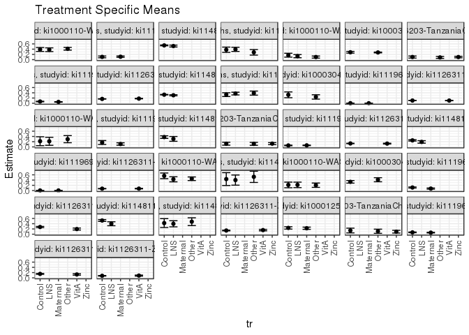

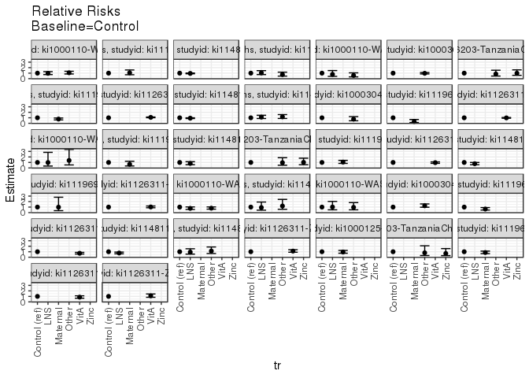

[figure not shown]

[figure not shown]

## Results Table

### Parameter: TSM

| mbmi | agecat | studyid | country | intervention_level | baseline_level | estimate | ci_lower | ci_upper |
| --- | --- | --- | --- | --- | --- | --- | --- | --- |
| [18.5-25) | Birth | ki1000304b-SAS-CompFeed | INDIA | Control | NA | 0.3225806 | 0.2120744 | 0.4330869 |
| [18.5-25) | Birth | ki1000304b-SAS-CompFeed | INDIA | Other | NA | 0.2413793 | 0.1585213 | 0.3242373 |
| [18.5-25) | Birth | ki1119695-PROBIT | BELARUS | Control | NA | 0.0038023 | 0.0027607 | 0.0048439 |
| [18.5-25) | Birth | ki1119695-PROBIT | BELARUS | Maternal | NA | 0.0011893 | 0.0003036 | 0.0020751 |
| [18.5-25) | Birth | ki1126311-ZVITAMBO | ZIMBABWE | Control | NA | 0.1051033 | 0.1014069 | 0.1087997 |
| [18.5-25) | Birth | ki1126311-ZVITAMBO | ZIMBABWE | VitA | NA | 0.1035945 | 0.0972239 | 0.1099651 |
| [18.5-25) | 6 months | ki1000110-WASH-Bangladesh | BANGLADESH | Control | NA | 0.1700000 | 0.0962920 | 0.2437080 |
| [18.5-25) | 6 months | ki1000110-WASH-Bangladesh | BANGLADESH | LNS | NA | 0.1333333 | 0.0724419 | 0.1942248 |
| [18.5-25) | 6 months | ki1000110-WASH-Bangladesh | BANGLADESH | Other | NA | 0.0990566 | 0.0587966 | 0.1393166 |
| [18.5-25) | 6 months | ki1000304b-SAS-CompFeed | INDIA | Control | NA | 0.2817680 | 0.2486066 | 0.3149294 |
| [18.5-25) | 6 months | ki1000304b-SAS-CompFeed | INDIA | Other | NA | 0.2744186 | 0.2590736 | 0.2897636 |
| [18.5-25) | 6 months | ki1066203-TanzaniaChild2 | TANZANIA, UNITED REPUBLIC OF | Control | NA | 0.1004367 | 0.0614831 | 0.1393902 |
| [18.5-25) | 6 months | ki1066203-TanzaniaChild2 | TANZANIA, UNITED REPUBLIC OF | Other | NA | 0.0857143 | 0.0478299 | 0.1235987 |
| [18.5-25) | 6 months | ki1066203-TanzaniaChild2 | TANZANIA, UNITED REPUBLIC OF | Zinc | NA | 0.0990338 | 0.0702434 | 0.1278243 |
| [18.5-25) | 6 months | ki1119695-PROBIT | BELARUS | Control | NA | 0.0676370 | 0.0567200 | 0.0785540 |
| [18.5-25) | 6 months | ki1119695-PROBIT | BELARUS | Maternal | NA | 0.0521353 | 0.0441989 | 0.0600718 |
| [18.5-25) | 6 months | ki1126311-ZVITAMBO | ZIMBABWE | Control | NA | 0.1665198 | 0.1610817 | 0.1719580 |
| [18.5-25) | 6 months | ki1126311-ZVITAMBO | ZIMBABWE | VitA | NA | 0.1791089 | 0.1694370 | 0.1887808 |
| [18.5-25) | 6 months | ki1148112-iLiNS-DOSE | MALAWI | Control | NA | 0.3280000 | 0.3185494 | 0.3374506 |
| [18.5-25) | 6 months | ki1148112-iLiNS-DOSE | MALAWI | LNS | NA | 0.3054264 | 0.2843655 | 0.3264872 |
| [18.5-25) | 6 months | ki1148112-LCNI-5 | MALAWI | Control | NA | 0.3292683 | 0.2572887 | 0.4012479 |
| [18.5-25) | 6 months | ki1148112-LCNI-5 | MALAWI | LNS | NA | 0.3701493 | 0.3184044 | 0.4218941 |
| [18.5-25) | 6 months | ki1148112-LCNI-5 | MALAWI | Other | NA | 0.3881579 | 0.3106254 | 0.4656904 |
| [18.5-25) | 24 months | ki1000110-WASH-Bangladesh | BANGLADESH | Control | NA | 0.3878788 | 0.3134769 | 0.4622806 |
| [18.5-25) | 24 months | ki1000110-WASH-Bangladesh | BANGLADESH | LNS | NA | 0.3785311 | 0.3070267 | 0.4500355 |
| [18.5-25) | 24 months | ki1000110-WASH-Bangladesh | BANGLADESH | Other | NA | 0.4145658 | 0.3634258 | 0.4657058 |
| [18.5-25) | 24 months | ki1119695-PROBIT | BELARUS | Control | NA | 0.1052632 | 0.0713077 | 0.1392186 |
| [18.5-25) | 24 months | ki1119695-PROBIT | BELARUS | Maternal | NA | 0.1115242 | 0.0852168 | 0.1378315 |
| [18.5-25) | 24 months | ki1148112-iLiNS-DOSE | MALAWI | Control | NA | 0.5436893 | 0.5276963 | 0.5596824 |
| [18.5-25) | 24 months | ki1148112-iLiNS-DOSE | MALAWI | LNS | NA | 0.5183752 | 0.4824311 | 0.5543194 |

[output cut: 56 more lines]

### Parameter: E(Y)

| mbmi | agecat | studyid | country | intervention_level | baseline_level | estimate | ci_lower | ci_upper |
| --- | --- | --- | --- | --- | --- | --- | --- | --- |
| [18.5-25) | Birth | ki1000304b-SAS-CompFeed | INDIA | NA | NA | 0.2833333 | 0.1434542 | 0.4232125 |
| [18.5-25) | Birth | ki1119695-PROBIT | BELARUS | NA | NA | 0.0024543 | 0.0009988 | 0.0039098 |
| [18.5-25) | Birth | ki1126311-ZVITAMBO | ZIMBABWE | NA | NA | 0.1039709 | 0.0966056 | 0.1113362 |
| [18.5-25) | 6 months | ki1000110-WASH-Bangladesh | BANGLADESH | NA | NA | 0.1250000 | 0.0937774 | 0.1562226 |
| [18.5-25) | 6 months | ki1000304b-SAS-CompFeed | INDIA | NA | NA | 0.2777778 | 0.2413281 | 0.3142275 |
| [18.5-25) | 6 months | ki1066203-TanzaniaChild2 | TANZANIA, UNITED REPUBLIC OF | NA | NA | 0.0961313 | 0.0763382 | 0.1159244 |
| [18.5-25) | 6 months | ki1119695-PROBIT | BELARUS | NA | NA | 0.0597750 | 0.0453286 | 0.0742213 |
| [18.5-25) | 6 months | ki1126311-ZVITAMBO | ZIMBABWE | NA | NA | 0.1759505 | 0.1648535 | 0.1870475 |
| [18.5-25) | 6 months | ki1148112-iLiNS-DOSE | MALAWI | NA | NA | 0.3090909 | 0.2860031 | 0.3321787 |
| [18.5-25) | 6 months | ki1148112-LCNI-5 | MALAWI | NA | NA | 0.3640553 | 0.3270653 | 0.4010453 |
| [18.5-25) | 24 months | ki1000110-WASH-Bangladesh | BANGLADESH | NA | NA | 0.3991416 | 0.3628113 | 0.4354720 |
| [18.5-25) | 24 months | ki1119695-PROBIT | BELARUS | NA | NA | 0.1086519 | 0.0656960 | 0.1516078 |
| [18.5-25) | 24 months | ki1148112-iLiNS-DOSE | MALAWI | NA | NA | 0.5225806 | 0.4832320 | 0.5619293 |
| [18.5-25) | 24 months | ki1148112-LCNI-5 | MALAWI | NA | NA | 0.3630363 | 0.3088016 | 0.4172710 |
| <18.5 | Birth | ki1126311-ZVITAMBO | ZIMBABWE | NA | NA | 0.1529412 | 0.1216726 | 0.1842098 |
| <18.5 | 6 months | ki1000110-WASH-Bangladesh | BANGLADESH | NA | NA | 0.2105263 | 0.1551227 | 0.2659300 |
| <18.5 | 6 months | ki1000304b-SAS-CompFeed | INDIA | NA | NA | 0.3720930 | 0.2781350 | 0.4660511 |
| <18.5 | 6 months | ki1119695-PROBIT | BELARUS | NA | NA | 0.0952381 | 0.0635513 | 0.1269249 |
| <18.5 | 6 months | ki1126311-ZVITAMBO | ZIMBABWE | NA | NA | 0.2130178 | 0.1693035 | 0.2567320 |
| <18.5 | 6 months | ki1148112-iLiNS-DOSE | MALAWI | NA | NA | 0.4191176 | 0.3358851 | 0.5023502 |
| <18.5 | 6 months | ki1148112-LCNI-5 | MALAWI | NA | NA | 0.4275862 | 0.3467820 | 0.5083904 |
| <18.5 | 24 months | ki1000110-WASH-Bangladesh | BANGLADESH | NA | NA | 0.4687500 | 0.4187732 | 0.5187268 |
| <18.5 | 24 months | ki1148112-LCNI-5 | MALAWI | NA | NA | 0.4516129 | 0.3267280 | 0.5764978 |
| [25-30) | Birth | ki1119695-PROBIT | BELARUS | NA | NA | 0.0028417 | -0.0001145 | 0.0057980 |
| [25-30) | Birth | ki1126311-ZVITAMBO | ZIMBABWE | NA | NA | 0.0737705 | 0.0621715 | 0.0853695 |
| [25-30) | 6 months | ki1066203-TanzaniaChild2 | TANZANIA, UNITED REPUBLIC OF | NA | NA | 0.1222222 | 0.0945706 | 0.1498739 |
| [25-30) | 6 months | ki1119695-PROBIT | BELARUS | NA | NA | 0.0580039 | 0.0433407 | 0.0726671 |
| [25-30) | 6 months | ki1126311-ZVITAMBO | ZIMBABWE | NA | NA | 0.1279070 | 0.1102537 | 0.1455603 |
| [25-30) | 6 months | ki1148112-iLiNS-DOSE | MALAWI | NA | NA | 0.2018779 | 0.1478449 | 0.2559110 |
| [25-30) | 24 months | ki1000110-WASH-Bangladesh | BANGLADESH | NA | NA | 0.2526316 | 0.1647910 | 0.3404722 |
| [25-30) | 24 months | ki1119695-PROBIT | BELARUS | NA | NA | 0.1357466 | 0.0470800 | 0.2244132 |
| [25-30) | 24 months | ki1148112-iLiNS-DOSE | MALAWI | NA | NA | 0.3205128 | 0.2162772 | 0.4247484 |
| >=30 | Birth | ki1126311-ZVITAMBO | ZIMBABWE | NA | NA | 0.0836237 | 0.0609578 | 0.1062896 |
| >=30 | 6 months | ki1000125-AgaKhanUniv | PAKISTAN | NA | NA | 0.2336957 | 0.1723832 | 0.2950081 |
| >=30 | 6 months | ki1066203-TanzaniaChild2 | TANZANIA, UNITED REPUBLIC OF | NA | NA | 0.1102041 | 0.0709127 | 0.1494955 |
| >=30 | 6 months | ki1119695-PROBIT | BELARUS | NA | NA | 0.0650224 | 0.0475829 | 0.0824619 |
| >=30 | 6 months | ki1126311-ZVITAMBO | ZIMBABWE | NA | NA | 0.1339950 | 0.1006954 | 0.1672947 |

### Parameter: RR

| mbmi | agecat | studyid | country | intervention_level | baseline_level | estimate | ci_lower | ci_upper |
| --- | --- | --- | --- | --- | --- | --- | --- | --- |
| [18.5-25) | Birth | ki1000304b-SAS-CompFeed | INDIA | Control | Control | 1.0000000 | 1.0000000 | 1.0000000 |
| [18.5-25) | Birth | ki1000304b-SAS-CompFeed | INDIA | Other | Control | 0.7482759 | 0.4607143 | 1.2153231 |
| [18.5-25) | Birth | ki1119695-PROBIT | BELARUS | Control | Control | 1.0000000 | 1.0000000 | 1.0000000 |
| [18.5-25) | Birth | ki1119695-PROBIT | BELARUS | Maternal | Control | 0.3127973 | 0.1412922 | 0.6924812 |
| [18.5-25) | Birth | ki1126311-ZVITAMBO | ZIMBABWE | Control | Control | 1.0000000 | 1.0000000 | 1.0000000 |
| [18.5-25) | Birth | ki1126311-ZVITAMBO | ZIMBABWE | VitA | Control | 0.9856449 | 0.9182359 | 1.0580024 |
| [18.5-25) | 6 months | ki1000110-WASH-Bangladesh | BANGLADESH | Control | Control | 1.0000000 | 1.0000000 | 1.0000000 |
| [18.5-25) | 6 months | ki1000110-WASH-Bangladesh | BANGLADESH | LNS | Control | 0.7843137 | 0.4178350 | 1.4722273 |
| [18.5-25) | 6 months | ki1000110-WASH-Bangladesh | BANGLADESH | Other | Control | 0.5826859 | 0.3216168 | 1.0556752 |
| [18.5-25) | 6 months | ki1000304b-SAS-CompFeed | INDIA | Control | Control | 1.0000000 | 1.0000000 | 1.0000000 |
| [18.5-25) | 6 months | ki1000304b-SAS-CompFeed | INDIA | Other | Control | 0.9739170 | 0.8550628 | 1.1092920 |
| [18.5-25) | 6 months | ki1066203-TanzaniaChild2 | TANZANIA, UNITED REPUBLIC OF | Control | Control | 1.0000000 | 1.0000000 | 1.0000000 |
| [18.5-25) | 6 months | ki1066203-TanzaniaChild2 | TANZANIA, UNITED REPUBLIC OF | Other | Control | 0.8534161 | 0.4740076 | 1.5365135 |
| [18.5-25) | 6 months | ki1066203-TanzaniaChild2 | TANZANIA, UNITED REPUBLIC OF | Zinc | Control | 0.9860323 | 0.6072785 | 1.6010113 |
| [18.5-25) | 6 months | ki1119695-PROBIT | BELARUS | Control | Control | 1.0000000 | 1.0000000 | 1.0000000 |
| [18.5-25) | 6 months | ki1119695-PROBIT | BELARUS | Maternal | Control | 0.7708110 | 0.6186787 | 0.9603524 |
| [18.5-25) | 6 months | ki1126311-ZVITAMBO | ZIMBABWE | Control | Control | 1.0000000 | 1.0000000 | 1.0000000 |
| [18.5-25) | 6 months | ki1126311-ZVITAMBO | ZIMBABWE | VitA | Control | 1.0756010 | 1.0098202 | 1.1456667 |
| [18.5-25) | 6 months | ki1148112-iLiNS-DOSE | MALAWI | Control | Control | 1.0000000 | 1.0000000 | 1.0000000 |
| [18.5-25) | 6 months | ki1148112-iLiNS-DOSE | MALAWI | LNS | Control | 0.9311779 | 0.8641248 | 1.0034341 |
| [18.5-25) | 6 months | ki1148112-LCNI-5 | MALAWI | Control | Control | 1.0000000 | 1.0000000 | 1.0000000 |
| [18.5-25) | 6 months | ki1148112-LCNI-5 | MALAWI | LNS | Control | 1.1241570 | 0.8672328 | 1.4571968 |
| [18.5-25) | 6 months | ki1148112-LCNI-5 | MALAWI | Other | Control | 1.1788499 | 0.8767101 | 1.5851159 |
| [18.5-25) | 24 months | ki1000110-WASH-Bangladesh | BANGLADESH | Control | Control | 1.0000000 | 1.0000000 | 1.0000000 |
| [18.5-25) | 24 months | ki1000110-WASH-Bangladesh | BANGLADESH | LNS | Control | 0.9759004 | 0.7455671 | 1.2773923 |
| [18.5-25) | 24 months | ki1000110-WASH-Bangladesh | BANGLADESH | Other | Control | 1.0688025 | 0.8508492 | 1.3425868 |
| [18.5-25) | 24 months | ki1119695-PROBIT | BELARUS | Control | Control | 1.0000000 | 1.0000000 | 1.0000000 |
| [18.5-25) | 24 months | ki1119695-PROBIT | BELARUS | Maternal | Control | 1.0594795 | 0.7104358 | 1.5800119 |
| [18.5-25) | 24 months | ki1148112-iLiNS-DOSE | MALAWI | Control | Control | 1.0000000 | 1.0000000 | 1.0000000 |
| [18.5-25) | 24 months | ki1148112-iLiNS-DOSE | MALAWI | LNS | Control | 0.9534402 | 0.8842635 | 1.0280286 |

[output cut: 56 more lines]

### Parameter: PAR

| mbmi | agecat | studyid | country | intervention_level | baseline_level | estimate | ci_lower | ci_upper |
| --- | --- | --- | --- | --- | --- | --- | --- | --- |
| [18.5-25) | Birth | ki1000304b-SAS-CompFeed | INDIA | Control | NA | -0.0392473 | -0.1274547 | 0.0489601 |
| [18.5-25) | Birth | ki1119695-PROBIT | BELARUS | Control | NA | -0.0013480 | -0.0023264 | -0.0003696 |
| [18.5-25) | Birth | ki1126311-ZVITAMBO | ZIMBABWE | Control | NA | -0.0011324 | -0.0075030 | 0.0052382 |
| [18.5-25) | 6 months | ki1000110-WASH-Bangladesh | BANGLADESH | Control | NA | -0.0450000 | -0.1073899 | 0.0173899 |
| [18.5-25) | 6 months | ki1000304b-SAS-CompFeed | INDIA | Control | NA | -0.0039902 | -0.0194713 | 0.0114909 |
| [18.5-25) | 6 months | ki1066203-TanzaniaChild2 | TANZANIA, UNITED REPUBLIC OF | Control | NA | -0.0043054 | -0.0373874 | 0.0287767 |
| [18.5-25) | 6 months | ki1119695-PROBIT | BELARUS | Control | NA | -0.0078620 | -0.0165132 | 0.0007892 |
| [18.5-25) | 6 months | ki1126311-ZVITAMBO | ZIMBABWE | Control | NA | 0.0094307 | -0.0002425 | 0.0191038 |
| [18.5-25) | 6 months | ki1148112-iLiNS-DOSE | MALAWI | Control | NA | -0.0189091 | -0.0399740 | 0.0021559 |
| [18.5-25) | 6 months | ki1148112-LCNI-5 | MALAWI | Control | NA | 0.0347870 | -0.0279736 | 0.0975476 |
| [18.5-25) | 24 months | ki1000110-WASH-Bangladesh | BANGLADESH | Control | NA | 0.0112628 | -0.0538689 | 0.0763946 |
| [18.5-25) | 24 months | ki1119695-PROBIT | BELARUS | Control | NA | 0.0033888 | -0.0229169 | 0.0296944 |
| [18.5-25) | 24 months | ki1148112-iLiNS-DOSE | MALAWI | Control | NA | -0.0211087 | -0.0570605 | 0.0148432 |
| [18.5-25) | 24 months | ki1148112-LCNI-5 | MALAWI | Control | NA | -0.0147415 | -0.0985730 | 0.0690901 |
| <18.5 | Birth | ki1126311-ZVITAMBO | ZIMBABWE | Control | NA | 0.0125903 | -0.0152339 | 0.0404145 |
| <18.5 | 6 months | ki1000110-WASH-Bangladesh | BANGLADESH | Control | NA | -0.0037594 | -0.0957141 | 0.0881953 |
| <18.5 | 6 months | ki1000304b-SAS-CompFeed | INDIA | Control | NA | 0.0387597 | -0.0411443 | 0.1186637 |
| <18.5 | 6 months | ki1119695-PROBIT | BELARUS | Control | NA | -0.0213538 | -0.0455248 | 0.0028171 |
| <18.5 | 6 months | ki1126311-ZVITAMBO | ZIMBABWE | Control | NA | -0.0609549 | -0.0986541 | -0.0232556 |
| <18.5 | 6 months | ki1148112-iLiNS-DOSE | MALAWI | Control | NA | -0.1026215 | -0.1782975 | -0.0269454 |
| <18.5 | 6 months | ki1148112-LCNI-5 | MALAWI | Control | NA | 0.0033438 | -0.1454126 | 0.1521001 |
| <18.5 | 24 months | ki1000110-WASH-Bangladesh | BANGLADESH | Control | NA | -0.0922256 | -0.1877506 | 0.0032994 |
| <18.5 | 24 months | ki1148112-LCNI-5 | MALAWI | Control | NA | 0.0141129 | -0.1972030 | 0.2254288 |
| [25-30) | Birth | ki1119695-PROBIT | BELARUS | Control | NA | -0.0000203 | -0.0022881 | 0.0022474 |
| [25-30) | Birth | ki1126311-ZVITAMBO | ZIMBABWE | Control | NA | 0.0011564 | -0.0089330 | 0.0112458 |
| [25-30) | 6 months | ki1066203-TanzaniaChild2 | TANZANIA, UNITED REPUBLIC OF | Control | NA | 0.0000848 | -0.0487645 | 0.0489342 |
| [25-30) | 6 months | ki1119695-PROBIT | BELARUS | Control | NA | 0.0018098 | -0.0076959 | 0.0113154 |
| [25-30) | 6 months | ki1126311-ZVITAMBO | ZIMBABWE | Control | NA | -0.0038296 | -0.0191289 | 0.0114698 |
| [25-30) | 6 months | ki1148112-iLiNS-DOSE | MALAWI | Control | NA | -0.0481221 | -0.0958875 | -0.0003566 |
| [25-30) | 24 months | ki1000110-WASH-Bangladesh | BANGLADESH | Control | NA | 0.0352403 | -0.1148540 | 0.1853346 |
| [25-30) | 24 months | ki1119695-PROBIT | BELARUS | Control | NA | -0.0326744 | -0.0794227 | 0.0140738 |
| [25-30) | 24 months | ki1148112-iLiNS-DOSE | MALAWI | Control | NA | -0.0544872 | -0.1465010 | 0.0375267 |
| >=30 | Birth | ki1126311-ZVITAMBO | ZIMBABWE | Control | NA | 0.0056095 | -0.0142724 | 0.0254914 |
| >=30 | 6 months | ki1000125-AgaKhanUniv | PAKISTAN | Control | NA | -0.0058877 | -0.0478867 | 0.0361114 |
| >=30 | 6 months | ki1066203-TanzaniaChild2 | TANZANIA, UNITED REPUBLIC OF | Control | NA | -0.0301468 | -0.1070192 | 0.0467256 |
| >=30 | 6 months | ki1119695-PROBIT | BELARUS | Control | NA | -0.0050223 | -0.0167945 | 0.0067500 |
| >=30 | 6 months | ki1126311-ZVITAMBO | ZIMBABWE | Control | NA | -0.0160050 | -0.0444046 | 0.0123947 |

### Parameter: PAF

| mbmi | agecat | studyid | country | intervention_level | baseline_level | estimate | ci_lower | ci_upper |
| --- | --- | --- | --- | --- | --- | --- | --- | --- |
| [18.5-25) | Birth | ki1000304b-SAS-CompFeed | INDIA | Control | NA | -0.1385199 | -0.5583354 | 0.1681973 |
| [18.5-25) | Birth | ki1119695-PROBIT | BELARUS | Control | NA | -0.5492395 | -1.3847918 | -0.0064372 |
| [18.5-25) | Birth | ki1126311-ZVITAMBO | ZIMBABWE | Control | NA | -0.0108913 | -0.0747699 | 0.0491907 |
| [18.5-25) | 6 months | ki1000110-WASH-Bangladesh | BANGLADESH | Control | NA | -0.3600000 | -0.9558491 | 0.0543238 |
| [18.5-25) | 6 months | ki1000304b-SAS-CompFeed | INDIA | Control | NA | -0.0143646 | -0.0725106 | 0.0406289 |
| [18.5-25) | 6 months | ki1066203-TanzaniaChild2 | TANZANIA, UNITED REPUBLIC OF | Control | NA | -0.0447865 | -0.4522333 | 0.2483448 |
| [18.5-25) | 6 months | ki1119695-PROBIT | BELARUS | Control | NA | -0.1315270 | -0.3118894 | 0.0240387 |
| [18.5-25) | 6 months | ki1126311-ZVITAMBO | ZIMBABWE | Control | NA | 0.0535984 | 0.0000837 | 0.1042490 |
| [18.5-25) | 6 months | ki1148112-iLiNS-DOSE | MALAWI | Control | NA | -0.0611765 | -0.1360442 | 0.0087573 |
| [18.5-25) | 6 months | ki1148112-LCNI-5 | MALAWI | Control | NA | 0.0955542 | -0.0943759 | 0.2525217 |
| [18.5-25) | 24 months | ki1000110-WASH-Bangladesh | BANGLADESH | Control | NA | 0.0282177 | -0.1494693 | 0.1784375 |
| [18.5-25) | 24 months | ki1119695-PROBIT | BELARUS | Control | NA | 0.0311891 | -0.2344564 | 0.2396697 |
| [18.5-25) | 24 months | ki1148112-iLiNS-DOSE | MALAWI | Control | NA | -0.0403931 | -0.1144998 | 0.0287859 |
| [18.5-25) | 24 months | ki1148112-LCNI-5 | MALAWI | Control | NA | -0.0406061 | -0.2991688 | 0.1664971 |
| <18.5 | Birth | ki1126311-ZVITAMBO | ZIMBABWE | Control | NA | 0.0823212 | -0.1009922 | 0.2351132 |
| <18.5 | 6 months | ki1000110-WASH-Bangladesh | BANGLADESH | Control | NA | -0.0178571 | -0.5633174 | 0.3372855 |
| <18.5 | 6 months | ki1000304b-SAS-CompFeed | INDIA | Control | NA | 0.1041667 | -0.1108971 | 0.2775952 |
| <18.5 | 6 months | ki1119695-PROBIT | BELARUS | Control | NA | -0.2242152 | -0.5824195 | 0.0529042 |
| <18.5 | 6 months | ki1126311-ZVITAMBO | ZIMBABWE | Control | NA | -0.2861492 | -0.5374616 | -0.0759161 |
| <18.5 | 6 months | ki1148112-iLiNS-DOSE | MALAWI | Control | NA | -0.2448513 | -0.4922832 | -0.0384454 |
| <18.5 | 6 months | ki1148112-LCNI-5 | MALAWI | Control | NA | 0.0078201 | -0.4088737 | 0.3012710 |
| <18.5 | 24 months | ki1000110-WASH-Bangladesh | BANGLADESH | Control | NA | -0.1967480 | -0.4203334 | -0.0083588 |
| <18.5 | 24 months | ki1148112-LCNI-5 | MALAWI | Control | NA | 0.0312500 | -0.5703651 | 0.4023832 |
| [25-30) | Birth | ki1119695-PROBIT | BELARUS | Control | NA | -0.0071551 | -1.2370702 | 0.5465670 |
| [25-30) | Birth | ki1126311-ZVITAMBO | ZIMBABWE | Control | NA | 0.0156754 | -0.1285948 | 0.1415033 |
| [25-30) | 6 months | ki1066203-TanzaniaChild2 | TANZANIA, UNITED REPUBLIC OF | Control | NA | 0.0006940 | -0.4907211 | 0.3301144 |
| [25-30) | 6 months | ki1119695-PROBIT | BELARUS | Control | NA | 0.0312007 | -0.1414448 | 0.1777333 |
| [25-30) | 6 months | ki1126311-ZVITAMBO | ZIMBABWE | Control | NA | -0.0299401 | -0.1608246 | 0.0861870 |
| [25-30) | 6 months | ki1148112-iLiNS-DOSE | MALAWI | Control | NA | -0.2383721 | -0.5708640 | 0.0237440 |
| [25-30) | 24 months | ki1000110-WASH-Bangladesh | BANGLADESH | Control | NA | 0.1394928 | -0.7146992 | 0.5681617 |
| [25-30) | 24 months | ki1119695-PROBIT | BELARUS | Control | NA | -0.2407018 | -0.7841441 | 0.1372105 |
| [25-30) | 24 months | ki1148112-iLiNS-DOSE | MALAWI | Control | NA | -0.1700000 | -0.5604030 | 0.1227267 |
| >=30 | Birth | ki1126311-ZVITAMBO | ZIMBABWE | Control | NA | 0.0670804 | -0.1835304 | 0.2646247 |
| >=30 | 6 months | ki1000125-AgaKhanUniv | PAKISTAN | Control | NA | -0.0251938 | -0.2271077 | 0.1434963 |
| >=30 | 6 months | ki1066203-TanzaniaChild2 | TANZANIA, UNITED REPUBLIC OF | Control | NA | -0.2735542 | -1.1942716 | 0.2608297 |
| >=30 | 6 months | ki1119695-PROBIT | BELARUS | Control | NA | -0.0772393 | -0.2920923 | 0.1018873 |
| >=30 | 6 months | ki1126311-ZVITAMBO | ZIMBABWE | Control | NA | -0.1194444 | -0.3843488 | 0.0947687 |